# (Prosper Loan Data Set)

## by (Ahmed Khaled Mohamed)

## Investigation Overview

It is the prosper loan data set, that contains information about loan listings and related variables including borrower as well as lender information. It contains variables related to Borrower such as credit rating, prosper rating etc. Moreover, the dataset also has lender information.

## Dataset Overview

The Prosper loan dataset contains 113,937 observations of 81 variables. The observations refer to loan listings on Prosper.com from late 2005 until 2014, and various characteristics of those loans. The data seems “tidy,” according to Hadley Wickham’s definition: the variable names are not variables themselves, so there is not much work required in the way of “tidying” the data.

```python
# import all packages and set plots to be embedded inline
import numpy as np
import pandas as pd
import matplotlib.pyplot as plt
import seaborn as sb

%matplotlib inline

# suppress warnings from final output
import warnings
warnings.simplefilter("ignore")
```

```python
# load the cleaned dataset for drawing
df = pd.read_csv('prosperLoanData.csv')
loan = pd.read_csv('loan_clean.csv')
```

> Note that the above cells have been set as "Skip"-type slides. That means that when the notebook is rendered as http slides, those cells won't show up.

## 1. Investor investigation

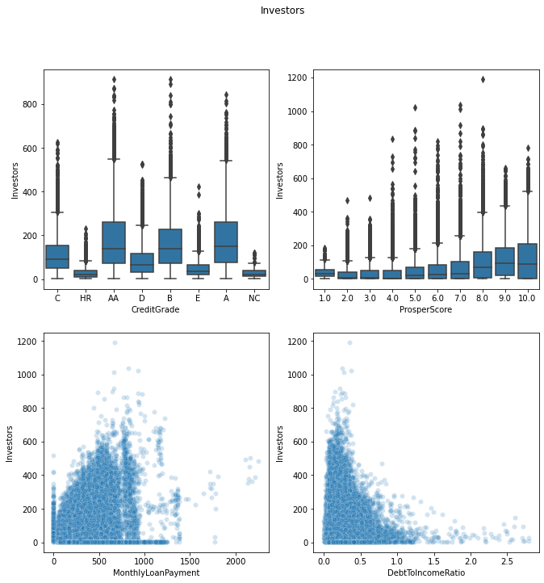

```python
plt.figure(figsize=[11, 11]);
plt.suptitle('Investors');

# Investors vs CreditGrade
plt.subplot(2, 2, 1);
base_color =  sb.color_palette()[0]
sb.boxplot(data=df, x='CreditGrade', y='Investors', color=base_color);
plt.xlabel('CreditGrade');
plt.ylabel('Investors');

# Investors vs ProsperScore
plt.subplot(2, 2, 2);
sb.boxplot(data=loan, x='ProsperScore', y='Investors', color=base_color);
plt.xlabel('ProsperScore');
plt.ylabel('Investors');

# Investors vs MonthlyLoanPayment
plt.subplot(2, 2, 3);
sb.scatterplot(data=loan, x='MonthlyLoanPayment', y='Investors', alpha= 0.2);
plt.xlabel('MonthlyLoanPayment');
plt.ylabel('Investors');

# Investors vs DebtToIncomeRatio
plt.subplot(2, 2, 4);
sb.scatterplot(data=loan, x='DebtToIncomeRatio', y='Investors', alpha= 0.2);
plt.xlabel('DebtToIncomeRatio');
plt.ylabel('Investors');
```

Investor number depend on the commetment of the borrower and it's highest credet grade and the lowerest risk of propsper score and lowest debt to income ratio.

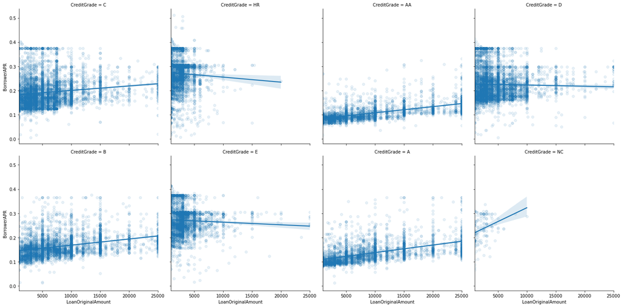

```python
# BorrowerAPR in terms of loan amount and duration
plt.figure(figsize=[11, 11]);
duration=sb.FacetGrid(data=df, col='CreditGrade', height=5, col_wrap=4)
duration.map(sb.regplot, 'LoanOriginalAmount', 'BorrowerAPR', x_jitter=0.04, scatter_kws={'alpha':0.1});
duration.add_legend();
```

The loan amount increases with better rating. The borrower APR decreases with better rating. Interestingly, the relationship between borrower APR and loan amount turns from negative to slightly positive when the Prosper ratings are increased from HR to A or better. This may because people with A or AA ratings tend to borrow more money, increasting APR could prevent them borrow even more and maximize the profit. But people with lower ratings tend to borrow less money, decreasing APR could encourage them to borrow more.

## 3. ProsperScore by loan duration

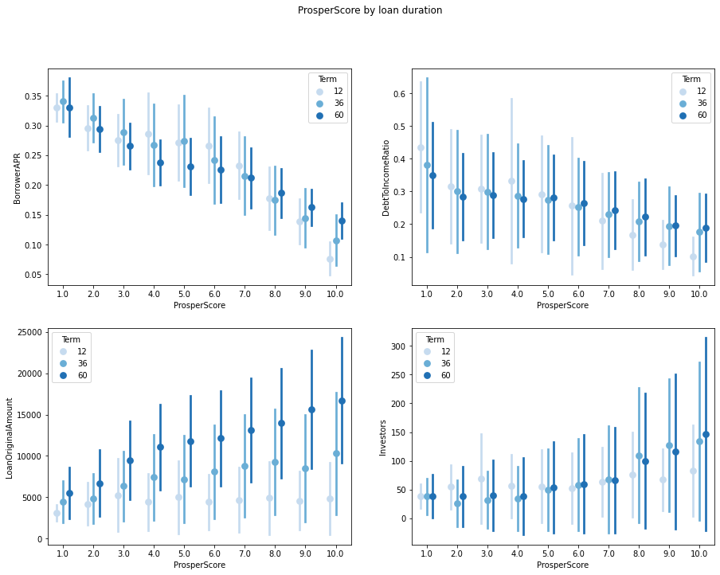

```python
plt.figure(figsize=[15, 11]);
plt.suptitle('ProsperScore by loan duration');

plt.subplot(2, 2, 1);
sb.pointplot(data = loan, x = 'ProsperScore', y = 'BorrowerAPR', hue = 'Term', palette = 'Blues', linestyles = '', dodge = 0.4, ci='sd')
plt.xlabel('ProsperScore');
plt.ylabel('BorrowerAPR');

plt.subplot(2, 2, 2);
sb.pointplot(data = loan, x = 'ProsperScore', y = 'DebtToIncomeRatio', hue = 'Term', palette = 'Blues', linestyles = '', dodge = 0.4, ci='sd')
plt.xlabel('ProsperScore');
plt.ylabel('DebtToIncomeRatio');

plt.subplot(2, 2, 3);
sb.pointplot(data = loan, x = 'ProsperScore', y = 'LoanOriginalAmount', hue = 'Term', palette = 'Blues', linestyles = '', dodge = 0.4, ci='sd')
plt.xlabel('ProsperScore');
plt.ylabel('LoanOriginalAmount');

plt.subplot(2, 2, 4);
sb.pointplot(data = loan, x = 'ProsperScore', y = 'Investors', hue = 'Term', palette = 'Blues', linestyles = '', dodge = 0.4, ci='sd')
plt.xlabel('ProsperScore');
plt.ylabel('Investors');
```

Interestingly, the borrower APR decreases with increasing Prosper rate. But for people with 4.0,7.0 ratings, the APR increase with the decrease of borrow term. Debt to income ration decreases with increasing the prosper score but nearly the sam in 2.0,3.0,4.0,5.0. Investor increases with increasing the prosper score. The loan original amount increases with terms and with prosper score.

## 4. Loan Origination Quarter

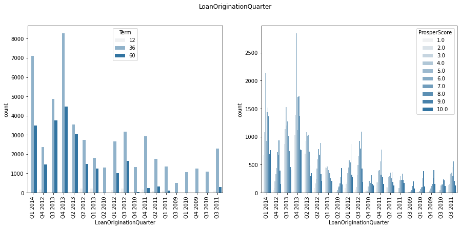

```python
plt.figure(figsize=[15, 6]);
plt.suptitle('LoanOriginationQuarter');
default_color = sb.color_palette()[0]
plt.subplot(1, 2, 1);
sb.countplot(data = loan, x = 'LoanOriginationQuarter', hue= 'Term', color = default_color)
plt.xticks(rotation=90);

plt.subplot(1, 2, 2);
sb.countplot(data = loan, x = 'LoanOriginationQuarter', hue= 'ProsperScore', color = default_color)
plt.xticks(rotation=90);
```

## 5. BorrowerAPR and EmploymentStatus for loan terms

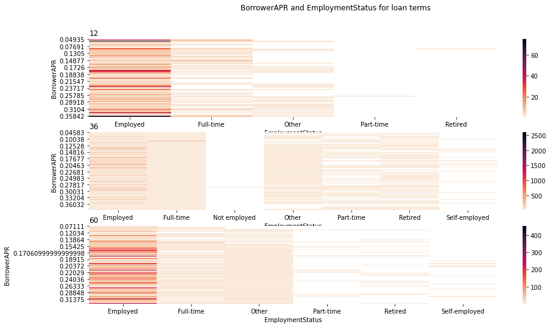

```python
plt.figure(figsize=[15, 8]);
plt.suptitle('BorrowerAPR and EmploymentStatus for loan terms');

# BorrowerAPR and EmploymentStatus for loan 12 months duration
plt.subplot(3, 1, 1)
duration = loan.query('Term == 12')
s = duration.groupby(['BorrowerAPR', 'EmploymentStatus']).size()
s = s.reset_index(name='count')
s = s.pivot(index='BorrowerAPR', columns='EmploymentStatus', values='count')
sb.heatmap(s, cmap='rocket_r');
plt.title('12', loc='left');
plt.xlabel('EmploymentStatus');
plt.ylabel('BorrowerAPR');

# BorrowerAPR and EmploymentStatus for loan 36 months duration
plt.subplot(3, 1, 2)

duration = loan.query('Term == 36')
s = duration.groupby(['BorrowerAPR', 'EmploymentStatus']).size()
s = s.reset_index(name='count')
s = s.pivot(index='BorrowerAPR', columns='EmploymentStatus', values='count')
sb.heatmap(s, cmap='rocket_r');
plt.title('36', loc='left');
plt.xlabel('EmploymentStatus');
plt.ylabel('BorrowerAPR');
# BorrowerAPR and EmploymentStatus for loan 60 months duration
plt.subplot(3, 1, 3)

duration = loan.query('Term == 60')
s = duration.groupby(['BorrowerAPR', 'EmploymentStatus']).size()
s = s.reset_index(name='count')
s = s.pivot(index='BorrowerAPR', columns='EmploymentStatus', values='count')
sb.heatmap(s, cmap='rocket_r');
plt.title('60', loc='left');
plt.xlabel('EmploymentStatus');
plt.ylabel('BorrowerAPR');
```

The most distributed data in whole loan term is employed status followed by full time status.

## 6. ProsperScore and EmploymentStatus

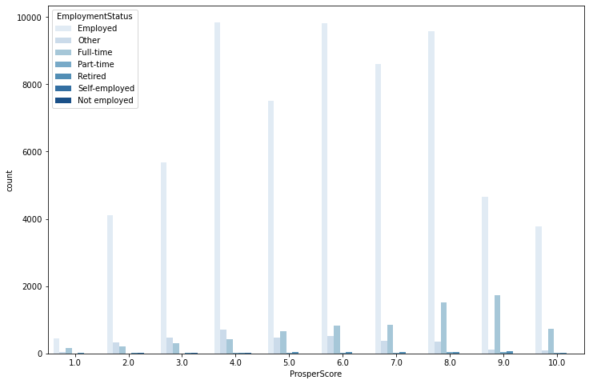

```python
plt.figure(figsize = [12, 8])
sb.countplot(data = loan, x = 'ProsperScore', hue = 'EmploymentStatus', palette='Blues');
```

> Once you're ready to finish your presentation, check your output by using nbconvert to export the notebook and set up a server for the slides. From the terminal or command line, use the following expression:

> > `jupyter nbconvert slide_deck_template.ipynb --to slides --post serve --template output_toggle.tpl`

> This should open a tab in your web browser where you can scroll through your presentation. Sub-slides can be accessed by pressing 'down' when viewing its parent slide. Make sure you remove all of the quote-formatted guide notes like this one before you finish your presentation!

## summary

In this analysis, I ran into difficulties from the sheer size of the data set. Not so much from the 114K observations, but from the 81 variables. There were so many different ways to slice and dice the data that it was easy to get lost at times. It also prompted me to ask some questions of the data that probably can’t be answered. For example, I wanted to reverse engineer the Prosper Score and Prosper Ratings algorithms, which I later learned wasn’t really possible.